# Chapter1 Statistics-Variables Types : Ravi Mummigatti : 23-12-20

# Goal

Review common variable types that one will work with in data , define these variable types and learn how to store them in Python using the pandas library.

Identifying variable types and storing them properly is an important first step for any statistical analysis. For one, different variable types require different methods for summarizing data and running hypothesis tests. Understanding your data will help you choose a method to answer your questions! It is also impossible to run any analysis in Python unless your computer can interpret your data correctly. If you store numerical values as strings, then you cannot calculate an average, for example

At the end of this module, you will be able to:

1. Identify the following variable types in a dataset:
2. Quantitative variables: continuous vs. discrete
3. Categorical variables: nominal vs. ordinal vs. binary
4. Load data in Python and check whether assigned data types match variable types
5. Encode categorical variables in Python using categorical encoding and one-hot encoding

**Prerequisites : Basic knowledge of Python and Pandas**

# Variable Types

In tabular data (eg., a spreadsheet), variables are represented by the columns of the spreadsheet. The types of variables within our dataset will have a great impact on the insights we can gain from our data. This is why it is important to understand variable types, and how different variables can offer different perspectives and functionalities within our data.

Generally, variables will come in two varieties; categorical and quantitative.

1. Categorical variables group observations into separate categories that can be ordered or unordered.
2. Quantitative variables on the other hand are variables expressed numerically, whether as a count or measurement.

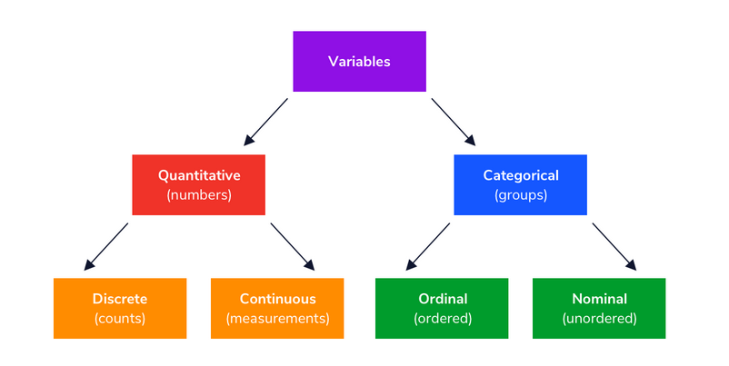

**Quantitative Variables**

We can think of quantitative variables as any information about an observation that can only be described with numbers. Quantitative variables are generally counts or measurements of something (eg., number of points earned in a game or height).There are two types of quantitative variables; discrete and continuous, and they both help to serve different functions in a dataset.

**Discrete Variables**  
Discrete quantitative variables are numeric values that represent counts and can only take on integer values. They represent whole units that can not be broken down into smaller pieces, and as such cannot be meaningfully expressed with decimals or fractions. Examples of discrete variables are the number of children in a person’s family or the number of coin flips a person makes.

**Continuous Variables** Continuous quantitative variables are numeric measurements that can be expressed with decimal precision. Theoretically, continuous variables can take on infinitely many values within a given range. Examples of continuous variables are length, weight, and age which can all be described with decimal values.

*Sometimes the line between discrete and continuous variables can be a bit blurry. For example, age with decimal values is a continuous variable, but age IN CLOSEST WHOLE YEARS by definition is discrete. The precision with which a quantitative variable is recorded can also determine how we classify the variable*

**Categorical Variables**

Categorical variables differ from quantitative variables in that they focus on the different ways data can be grouped rather than counted or measured. With categorical variables, we want to understand how the observations in our dataset can be grouped and separated from one another based on their attributes.There are two types of categorical variables : Ordinal and Nominal.

**Ordinal Variables**  
*When the groupings of a categorical variable have a specific order or ranking , it is an ordinal variable.*  
Suppose there was a variable containing responses to the question “Rate your agreement with the statement: The minimum age to drive should be lowered.” The response options are “strongly disagree”, “disagree”, “neutral”, “agree”, and “strongly agree”.Because we can see an order where “strongly disagree” < “disagree “ < “neutral” < “agree” < “strongly agree” in relation to agreement, we consider the variable to be ordinal

**Nominal Variables**  
*If there is no apparent order/ranking to the categories of a categorical variable, we refer to to it as a nominal variable.*  
Nominal categorical variables are those variables with two or more categories that do not have any relational order. Examples of nominal categories could be states in the U.S., brands of computers, or ethnicities. Notice how for each of these variables, there is no intrinsic ordering that distinguishes a category as greater than or less than another category.  
*The number of possible values for a nominal variable can be quite large. It’s even possible that a nominal categorical variable will take on a unique value for every observation in a dataset, like in the case of unique identifiers such as name or email_addres*

**Binary Variables**  
*Binary or dichotomous variables are a special kind of nominal variable that have only two categories.*  
Because there are only two possible values for binary variables, they are mutually exclusive to one another. We can imagine a variable that describes if a picture contains a cat or a dog as a binary variable. In this case, if the picture is not a dog, it must be a cat, and vice versa. Binary variables can also be described with numbers similar to bits with 0 or 1 values. Likewise you may find binary variables containing boolean values of True or False.

**Assessing Variable Types**  
An important first step to working with datasets is figuring out what kind of variables (columns in a dataframe) are present, and whether they are quantitative or categorical.

An effective way of taking a peek into our dataframes in pandas is to look at the first few rows of the data. This helps us learn the variable names within our dataset, and get a sample of the values in each variable, which are invaluable bits of information for us to understand what types of variables we have in our data.

Inspecting our dataset gives us a better understanding of the data that we are working with and the kinds of operations that will be possible, but looking at the data can only tell us so much! Sometimes the variable type of the data may be unclear.

In these cases, we may need to confirm our assessments by inspecting the data dictionary or using domain knowledge. Researching through the associated documentation and a little domain knowledge can often save us from any false assumptions we may have made about our dataset.

Let’s practice inspecting a dataset to identify its variable types by working with the movies dataframe which is composed of the television shows and movies hosted on the Netflix platform in 2019.

```python
# import packages
import pandas as pd

# load the dataset
movies = pd.read_csv("movie_data_netflix.csv" , engine='python')

# inspect the top 5 rows
movies.head()
```

|  | type | title | country | release_year | rating | duration |
| --- | --- | --- | --- | --- | --- | --- |
| 0 | Movie | Norm of the ... | United States | missing | PG | 91.071 |
| 1 | Movie | Jandino: Wha... | United Kingdom | 2016 | R | 94.516 |
| 2 | TV Show | Transformers... | United States | 2013 | G | 1.127 |
| 3 | TV Show | Transformers... | United States | 2016 | TV-14 | 1.687 |
| 4 | Movie | #realityhigh... | United States | 2017 | TV-14 | 99.248 |

**Categorical Variables**

The rating variable describes the Motion Picture Association Film Rating Board rating for each film and the TV Parental Guidelines Monitoring Board rating for each television show. The ratings have been consolidated for simplicity.

**Question : Identify whether the rating variable is quantitative or categorical?**  
**Answer : Rating is a "Categorical Varibale" as is evident from the "different categories of movie ratings".**

Suppose that you’ve looked at the first few rows of your data and established that a variable is categorical. An important next step is to determine whether the categories are ordered or not.  
We can use **.unique()** to view the unique values in the variable to further inspect their data types

```python
# unique values of country
movies['country'].unique()
```

```
array(['United States', 'United Kingdom', 'Spain', 'Bulgaria', 'Chile',
       nan, 'Netherlands', 'France', 'Thailand', 'China', 'Belgium',
       'India', 'Pakistan', 'Canada', 'South Korea', 'Denmark', 'Turkey',
       'Brazil', 'Indonesia', 'Ireland', 'Hong Kong', 'Mexico', 'Vietnam',
       'Nigeria', 'Japan', 'Norway', 'Lebanon', 'Cambodia', 'Russia',
       'Poland', 'Israel', 'Italy', 'Germany', 'United Arab Emirates',
       'Egypt', 'Taiwan', 'Australia', 'Czech Republic', 'Argentina',
       'Switzerland', 'Malaysia', 'Philippines', 'Serbia', 'Colombia',
       'Singapore', 'Peru', 'South Africa', 'New Zealand', 'Venezuela',
       'Saudi Arabia', 'Iceland', 'Austria', 'Uruguay', 'Finland',
       'Ghana', 'Iran', 'Sweden', 'Hungary', 'Guatemala', 'Portugal',
       'Paraguay', 'Somalia', 'Ukraine', 'Dominican Republic', 'Romania',
       'Slovenia', 'Croatia', 'Bangladesh', 'Soviet Union', 'Georgia',
       'West Germany', 'Mauritius', 'Cyprus'], dtype=object)
```

**Question : Identify whether the country column is ordinal or nominal**  
**Answer : Nominal , given that there is no specific order**

```python
# unique values of rating
movies['rating'].unique()
```

```
array(['PG', 'R', 'G', 'TV-14', 'PG-13', 'UNRATED', 'NOT RATED'],
      dtype=object)
```

**Quantitative Variables**  
As with categorical variables, it is important to closely examine quantitative variables in a dataset and understand what they are measuring. There are two different types of quantitative variables: discrete and continuous.

1. Discrete quantitative variables are counts, so they should be whole numbers (no decimals)
2. Continuous quantitative variables are measurements so they should be decimals (look for those values that are measured and in decimal form)

```python
# firt 5 rows
movies.head()
```

|  | type | title | country | release_year | rating | duration |
| --- | --- | --- | --- | --- | --- | --- |
| 0 | Movie | Norm of the ... | United States | missing | PG | 91.071 |
| 1 | Movie | Jandino: Wha... | United Kingdom | 2016 | R | 94.516 |
| 2 | TV Show | Transformers... | United States | 2013 | G | 1.127 |
| 3 | TV Show | Transformers... | United States | 2016 | TV-14 | 1.687 |
| 4 | Movie | #realityhigh... | United States | 2017 | TV-14 | 99.248 |

```python
# last 5 rows
movies.tail()
```

|  | type | title | country | release_year | rating | duration |
| --- | --- | --- | --- | --- | --- | --- |
| 6229 | TV Show | Red vs. Blue... | United States | 2015 | R | 13.101 |
| 6230 | TV Show | Maron... | United States | 2016 | R | 4.122 |
| 6231 | Movie | Little Baby ... | NaN | 2016 | UNRATED | 60.362 |
| 6232 | TV Show | A Young Doct... | United Kingdom | 2013 | R | 2.082 |
| 6233 | TV Show | Friends... | United States | 2003 | TV-14 | 10.972 |

**Question : Identify the type of "Release Year"**  
**Answer : Release Year is a "discrete numerical variable" since these are countable.**

**Question : Identify the type of "Duration"**  
**Answer : Duration is a "continuous numerical variable" since this is in decimals and cannot be easily counted**

**Matching Quantitative Variables**  
When we read a data file into a Python environment, data types are assigned to each column.  
These data types should match the values contained in the column. e.g. if a column contains only integer values, it will likely get stored as an integer.

This doesn’t always work perfectly, so it’s important that we inspect the data types that were assigned to each variable and make sure they match up with the variable types.

When using Python, Pandas dataframe data types can be inspected using the **.dtypes** attribute.

- Continuous quantitative variables should usually be represented as **float**. Floats allow us to store decimal values, which is important for continuous variables like price with decimal precision we don’t want to lose.
- Discrete quantitative variables are often represented by the **int** datatype. This is because they should never contain decimal values, and an integer doesn’t store decimals. It’s important to keep in mind that int values are not always indicative of discrete quantitative variables. Sometimes categorical variables can be expressed with int values.

Using int and float to store quantitative variables is important so that we can later perform numerical operations on those values or fit models that interpret the values as numbers. If weu store these variables as str, for instance, we wouldn’t be able to do something like calculate the mean or standard deviation.

**A useful way of assessing data types in Pandas is the .info() method, which returns the number of instances in each column along with the data types, a tally of the data types, and the dataframe memory usage**

```python
# using dtypes
movies.dtypes
```

```
type             object
title            object
country          object
release_year     object
rating           object
duration        float64
dtype: object
```

```python
# using .info
movies.info()
```

```
<class 'pandas.core.frame.DataFrame'>
RangeIndex: 6234 entries, 0 to 6233
Data columns (total 6 columns):
 #   Column        Non-Null Count  Dtype
---  ------        --------------  -----
 0   type          6234 non-null   object
 1   title         6234 non-null   object
 2   country       5758 non-null   object
 3   release_year  6234 non-null   object
 4   rating        6234 non-null   object
 5   duration      6234 non-null   float64
dtypes: float64(1), object(5)
memory usage: 292.3+ KB
```

**Inference : We have 5 "object type i.e. string variables" and 1 "float variable"**

**Question : What are the data types of the two quantitative variables: release_year and duration? Are these data types appropriate for these variables?**  
**Answer : Release_Year should be a "Quantitative Discrete Variable i.e. int" since "Years can be counted" whilst Duration is the correct type float**

**Matching Categorical Variables**  
As we did for Quantitative variables , we should also make sure that our variable types and data types match for categorical variables as well.

1. Nominal variables are often represented by the **str** data type, which is short for “string”. The .dtypes accessor will return the string data types as object.
2. Ordinal variables are generally represented by **int and str** data types.
3. Binary variables can be represented with the **bool, int, and str** data types.

**One should pay extra attention to categorical variables with int data types. e.g. if you have a nominal variable called group_number which contains the categories 1, 2, and 3 stored as int, your computer will interpret these values as numbers rather than the names of groups within your variable**

```python
# data types
movies.dtypes
```

```
type             object
title            object
country          object
release_year     object
rating           object
duration        float64
dtype: object
```

```python
# 1st 5 rows
movies.head()
```

|  | type | title | country | release_year | rating | duration |
| --- | --- | --- | --- | --- | --- | --- |
| 0 | Movie | Norm of the ... | United States | missing | PG | 91.071 |
| 1 | Movie | Jandino: Wha... | United Kingdom | 2016 | R | 94.516 |
| 2 | TV Show | Transformers... | United States | 2013 | G | 1.127 |
| 3 | TV Show | Transformers... | United States | 2016 | TV-14 | 1.687 |
| 4 | Movie | #realityhigh... | United States | 2017 | TV-14 | 99.248 |

**Applying the "len" method to the "type" column with unique() gives us the number of sub-categories within the categorical variable. This also helps us assess the number of unique categories within a categorical variable**

```python
print(movies['type'].unique())
print(len(movies['type'].unique()))
```

```
['Movie' 'TV Show']
2
```

```python
len(movies['title'].unique())
```

```
5731
```

```python
len(movies['country'].unique())
```

```
73
```

```python
len(movies['rating'].unique())
```

```
7
```

**Making a habit of checking each variable name and what it describes in your dataset, then comparing that to the data type that is assigned to it will save you time and ensure you get the most insight from your data**

# Altering the Data Types of Pandas Dataframes

Sometimes, the data types that are automatically assigned to variables may not be appropriate. This can be problematic because the data type determines the kind of operations that can be performed on a variable. Also, incorrect assignment of variable types can eliminate important information (like the order of the categories). If it is clear that an incorrect data-type has been assigned to a variable, there are two options:

a) Read the data into Python in a different way (eg., alter the call to .read_csv())

b) Change the data-type directly

We can use the **astype()** method to alter the data type of a variable.

The .astype() method is one of the most effective ways of altering the data type of a column. It can cast any column within a pandas dataframe to the data type of your choosing, as long as the translation is relatively obvious.

The astype() function is smart enough to know that the character "1" should translate to the integer 1; However, it won’t know how to convert the character string "one" to an integer.

**Number can be converted to a string but not vice versa. Number in "" is a string and can be converted to Number directly with astype() method**

```python
# 1st five rows
movies.head()
```

|  | type | title | country | release_year | rating | duration |
| --- | --- | --- | --- | --- | --- | --- |
| 0 | Movie | Norm of the ... | United States | missing | PG | 91.071 |
| 1 | Movie | Jandino: Wha... | United Kingdom | 2016 | R | 94.516 |
| 2 | TV Show | Transformers... | United States | 2013 | G | 1.127 |
| 3 | TV Show | Transformers... | United States | 2016 | TV-14 | 1.687 |
| 4 | Movie | #realityhigh... | United States | 2017 | TV-14 | 99.248 |

There is a missing value in the release_year variable for a movie that was released in 2019 denoted by the string 'missing'.  
To change the datatype of variable, first convert this value from missing to 2019 with the .replace() method.  
Here we are replacing the "word missing" with the "word 2019".  
The reason we are replacing with '2019' is because Release Year is "Object Type" , stored as a string

```python
# Print the mean of the release_year variable using the pandas .mean() method
#movies['release_year'].mean()
```

**We will get a value Error because we cannot find the mean of a categorical varaible despite it reflceting as a number**

```python
# replace missing with 2019
movies['release_year'] = movies['release_year'].replace('missing' , 2019)
movies.head()
```

|  | type | title | country | release_year | rating | duration |
| --- | --- | --- | --- | --- | --- | --- |
| 0 | Movie | Norm of the ... | United States | 2019 | PG | 91.071 |
| 1 | Movie | Jandino: Wha... | United Kingdom | 2016 | R | 94.516 |
| 2 | TV Show | Transformers... | United States | 2013 | G | 1.127 |
| 3 | TV Show | Transformers... | United States | 2016 | TV-14 | 1.687 |
| 4 | Movie | #realityhigh... | United States | 2017 | TV-14 | 99.248 |

Change the data type of the release_year variable from object to int with .astype()

```python
# change datatype of release_year from object to int
movies['release_year'] = movies['release_year'].astype('int')

# Recheck the data types with .dtypes.
movies.dtypes
```

```
type             object
title            object
country          object
release_year      int32
rating           object
duration        float64
dtype: object
```

```python
# Print the mean of the release_year variable using the pandas .mean() method
movies['release_year'].mean()
```

```
2013.3593198588387
```

# The Pandas Category Data Type

For ordinal categorical variables, we often want to store two different pieces of information: category labels and their order. None of the data types we’ve covered so far can store both of these at once.

For example, let’s take another look at the rating column in our movies dataframe, which contains movie ratings stored as strings. We can use the .unique() method to inspect the category names:

```python
movies['rating'].unique()
```

```
array(['PG', 'R', 'G', 'TV-14', 'PG-13', 'UNRATED', 'NOT RATED'],
      dtype=object)
```

At this point, Python does not know that these categories have an inherent order.  
There is a specific data type for categorical variables in pandas called **category** to address this problem.  
The pandas **.Categorical()** method can be used to store data as type category and indicate the order of the categories.

```python
movies['rating'] = pd.Categorical(movies['rating'], ['G', 'PG', 'PG-13', 'TV-14' , 'R','UNRATED', 'NOT RATED'], ordered=True)
```

Now, not only does Python recognize that the rating column is an ordinal variable, it understands that G < PG < PG-13 < TV-14 < R < UNRATED < NOT RATED. If we call .unique() on this column again, we see how Python retains the correct rankings.

```python
movies['rating'].unique()
```

```
['PG', 'R', 'G', 'TV-14', 'PG-13', 'UNRATED', 'NOT RATED']
Categories (7, object): ['G' < 'PG' < 'PG-13' < 'TV-14' < 'R' < 'UNRATED' < 'NOT RATED']
```

This is very helpful in the event that we would like to sort the column by category; if we use .sort_values(), the dataframe will be sorted by the logical order of the rating column as opposed to the alphabetical order.

The clothes dataframe is a dataset focusing on the reviews of an Ecommerce store.  
Let's review the data for data tupes and correct errors if any

```python
# load the data into a dataframe and view top 5 rows
clothes = pd.read_csv("clothes_data.csv")
clothes.head()
```

|  | Clothing ID | Age | Title | Rating | Division Name |
| --- | --- | --- | --- | --- | --- |
| 0 | 767 | 33 | NaN | satisfied | Initmates |
| 1 | 1080 | 34 | NaN | very satisfied | General |
| 2 | 1077 | 60 | Some major design flaws | neutral | General |
| 3 | 1049 | 50 | My favorite buy! | very satisfied | General Petite |
| 4 | 847 | 47 | Flattering shirt | very satisfied | General |

```python
# print unique values of Rating
clothes['Rating'].unique()
```

```
array(['satisfied', 'very satisfied', 'neutral', 'unsatisfied',
       'very unsatisfied'], dtype=object)
```

We have 5 different ratings. Now Let us change the data type of the Rating variable to categorical and set an order of ['very unsatisfied', 'unsatisfied', 'neutral', 'satisfied', 'very satisfied']

```python
# assign order and change Rating to category
clothes['Rating'] = pd.Categorical(clothes['Rating'],['very unsatisfied', 'unsatisfied', 'neutral', 'satisfied', 'very satisfied'], ordered=True)
```

```python
# Recheck the values of `Rating` with .unique()
clothes['Rating'].unique()
```

```
['satisfied', 'very satisfied', 'neutral', 'unsatisfied', 'very unsatisfied']
Categories (5, object): ['very unsatisfied' < 'unsatisfied' < 'neutral' < 'satisfied' < 'very satisfied']
```

# Label Encoding with .cat.codes

When working with categorical variables, it is sometimes necessary to convert the categories to numbers. This is called **categorical encoding** and can be achieved through several encoding methods.

Label encoding is when we specifically **convert each category in a variable to an integer**. This enables us to perform numerical operations on the column.

In order to perform label encoding in pandas, we can use the **.cat.codes accessor** for any variable stored as type **category**

In the following example, the Education variable has four unique categories: high school diploma, associates, bachelors, and post doctorate. The .cat.codes accessor will convert the categories into numeric values

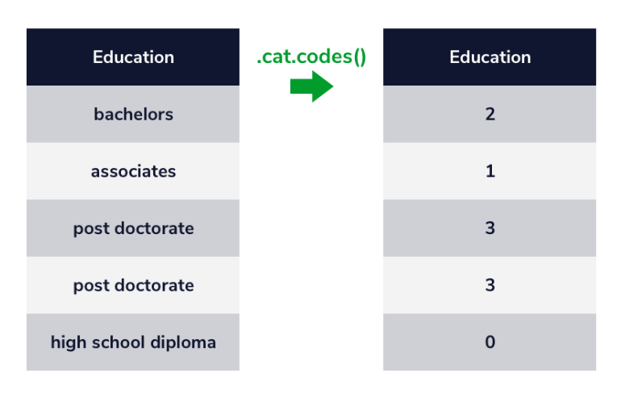

Note :

1. Education has to be first converted to a categorical type by alpplying the pd.Categorical method with the specified order where-in High School Diploma < Associates < Bachelors < Post Doctrate..
2. We then apply the .cat.codes accessor to convert eduation to numerical variables with the approproate codes

**Applying Label Encoding to Rating column fo Clothes**

```python
# load the data into a dataframe and view top 5 rows
myclothes = pd.read_csv("clothes_data.csv")
myclothes.head()
```

|  | Clothing ID | Age | Title | Rating | Division Name |
| --- | --- | --- | --- | --- | --- |
| 0 | 767 | 33 | NaN | satisfied | Initmates |
| 1 | 1080 | 34 | NaN | very satisfied | General |
| 2 | 1077 | 60 | Some major design flaws | neutral | General |
| 3 | 1049 | 50 | My favorite buy! | very satisfied | General Petite |
| 4 | 847 | 47 | Flattering shirt | very satisfied | General |

```python
# ratings unique
myclothes['Rating'].unique()
```

```
array(['satisfied', 'very satisfied', 'neutral', 'unsatisfied',
       'very unsatisfied'], dtype=object)
```

```python
# Convert to categorical with appropropriate order
myclothes['Rating'] = pd.Categorical(clothes['Rating'], ['very unsatisfied', 'unsatisfied', 'neutral',
                                                       'satisfied', 'very satisfied'], ordered=True)
myclothes['Rating'].unique()
```

```
['satisfied', 'very satisfied', 'neutral', 'unsatisfied', 'very unsatisfied']
Categories (5, object): ['very unsatisfied' < 'unsatisfied' < 'neutral' < 'satisfied' < 'very satisfied']
```

```python
# Create a new variable rating_codes, which contains the numerical codes associated with each category
myclothes['rating_code'] = myclothes['Rating'].cat.codes
```

```python
# 1st five rows
myclothes.head()
```

|  | Clothing ID | Age | Title | Rating | Division Name | rating_code |
| --- | --- | --- | --- | --- | --- | --- |
| 0 | 767 | 33 | NaN | satisfied | Initmates | 3 |
| 1 | 1080 | 34 | NaN | very satisfied | General | 4 |
| 2 | 1077 | 60 | Some major design flaws | neutral | General | 2 |
| 3 | 1049 | 50 | My favorite buy! | very satisfied | General Petite | 4 |
| 4 | 847 | 47 | Flattering shirt | very satisfied | General | 4 |

**Applying Label Encoding to rating column of movies**

```python
# load the data into a dataframe and view top 5 rows
mymovies = pd.read_csv("movie_data_netflix.csv" , engine='python')
mymovies.head()
```

|  | type | title | country | release_year | rating | duration |
| --- | --- | --- | --- | --- | --- | --- |
| 0 | Movie | Norm of the ... | United States | missing | PG | 91.071 |
| 1 | Movie | Jandino: Wha... | United Kingdom | 2016 | R | 94.516 |
| 2 | TV Show | Transformers... | United States | 2013 | G | 1.127 |
| 3 | TV Show | Transformers... | United States | 2016 | TV-14 | 1.687 |
| 4 | Movie | #realityhigh... | United States | 2017 | TV-14 | 99.248 |

```python
# ratings unique
mymovies['rating'].unique()
```

```
array(['PG', 'R', 'G', 'TV-14', 'PG-13', 'UNRATED', 'NOT RATED'],
      dtype=object)
```

```python
# Convert to categorical with appropropriate order
mymovies['rating'] = pd.Categorical(mymovies['rating'] , ['G', 'PG', 'PG-13', 'TV-14' , 'R',
                                                          'UNRATED', 'NOT RATED'], ordered=True)
mymovies['rating'].unique()
```

```
['PG', 'R', 'G', 'TV-14', 'PG-13', 'UNRATED', 'NOT RATED']
Categories (7, object): ['G' < 'PG' < 'PG-13' < 'TV-14' < 'R' < 'UNRATED' < 'NOT RATED']
```

```python
# Create a new variable rating_codes, which contains the numerical codes associated with each category
mymovies['rating_code'] = mymovies['rating'].cat.codes
```

```python
mymovies.head()
```

|  | type | title | country | release_year | rating | duration | rating_code |
| --- | --- | --- | --- | --- | --- | --- | --- |
| 0 | Movie | Norm of the ... | United States | missing | PG | 91.071 | 1 |
| 1 | Movie | Jandino: Wha... | United Kingdom | 2016 | R | 94.516 | 4 |
| 2 | TV Show | Transformers... | United States | 2013 | G | 1.127 | 0 |
| 3 | TV Show | Transformers... | United States | 2016 | TV-14 | 1.687 | 3 |
| 4 | Movie | #realityhigh... | United States | 2017 | TV-14 | 99.248 | 3 |

# One-Hot Encoding

We have seen how label encoding can be useful for ordinal categorical variables. But sometimes we need a different approach. This could be because:

1. We have a nominal categorical variable (like breed of Dog), so it doesn’t really make sense to assign numbers like 0,1,2,3,4,5 to our categories, as this could create an order among the species that is not present.
2. We have an ordinal categorical variable but we don’t want to assume that there’s equal spacing between categories.

Another way of encoding categorical variables is called **One-Hot Encoding (OHE)**. With OHE, we essentially create a new binary variable for each of the categories within our original variable. **This technique is useful when managing nominal variables because it encodes the variable without creating an order among the categories.**

To perform OHE on a variable within a pandas dataframe, we can use the pandas **.get_dummies()** method which creates a binary or “dummy” variable for each category. We can assign the columns to be encoded in the columns parameter, and set the data parameter to the dataset we intend to alter. The pd.get_dummies() method will also work on data types other than category..

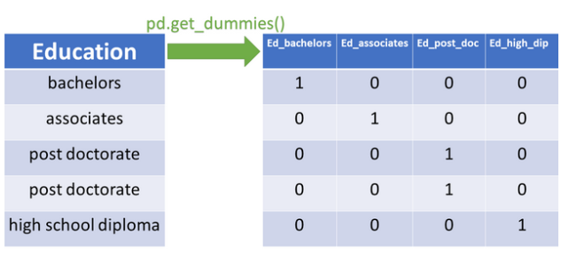

```python
# load cereals data set
cereal = pd.read_csv("nestle_cereals_data.csv")
cereal.head()
```

|  | id | name | mfr | type | fiber | rating | shelf | vitamins | coupons | price |
| --- | --- | --- | --- | --- | --- | --- | --- | --- | --- | --- |
| 0 | 0 | 100% Bran | Nestle | C | 10.0 | 68.40 | top | 25 | 4 | 4.06 |
| 1 | 1 | 100% Natural Bran | Quaker Oats | C | 2.0 | 33.98 | top | 0 | 1 | 4.62 |
| 2 | 2 | All-Bran | Kelloggs | C | 9.0 | 59.43 | top | 25 | 3 | 4.39 |
| 3 | 3 | All-Bran with Extra Fiber | Kelloggs | C | 14.0 | 93.70 | top | 25 | 2 | 6.18 |
| 4 | 4 | Almond Delight | Ralston Purina | C | 1.0 | 34.38 | top | 25 | 2 | 6.05 |

```python
# unique cereal manufacturers
cereal['mfr'].unique()
```

```
array(['Nestle', 'Quaker Oats', 'Kelloggs', 'Ralston Purina',
       'General Mills', 'Post', 'American Home'], dtype=object)
```

```python
# count of uniquecereal manufacturers
len(cereal['mfr'].unique())
```

```
7
```

```python
# One-Hot Encode the mfr variable with pd.get_dummies()
cereal = pd.get_dummies(data = cereal , columns = ['mfr'])
```

```python
# relook at top 5 rows
cereal.head().T
```

|  | 0 | 1 | 2 | 3 | 4 |
| --- | --- | --- | --- | --- | --- |
| id | 0 | 1 | 2 | 3 | 4 |
| name | 100% Bran | 100% Natural Bran | All-Bran | All-Bran with Extra Fiber | Almond Delight |
| type | C | C | C | C | C |
| fiber | 10 | 2 | 9 | 14 | 1 |
| rating | 68.4 | 33.98 | 59.43 | 93.7 | 34.38 |
| shelf | top | top | top | top | top |
| vitamins | 25 | 0 | 25 | 25 | 25 |
| coupons | 4 | 1 | 3 | 2 | 2 |
| price | 4.06 | 4.62 | 4.39 | 6.18 | 6.05 |
| mfr_American Home | 0 | 0 | 0 | 0 | 0 |
| mfr_General Mills | 0 | 0 | 0 | 0 | 0 |
| mfr_Kelloggs | 0 | 0 | 1 | 1 | 0 |
| mfr_Nestle | 1 | 0 | 0 | 0 | 0 |
| mfr_Post | 0 | 0 | 0 | 0 | 0 |
| mfr_Quaker Oats | 0 | 1 | 0 | 0 | 0 |
| mfr_Ralston Purina | 0 | 0 | 0 | 0 | 1 |

**7 Columns have been created , 1 per manufacturer category... Column Names have a pre-fix mfr_ denoting this is the dummy codec column and value of "1" implies True i.e. mfr_Post = 1 implies manufacturer is "Post". Notice also that the original "mfr" column is dropped from the new DataFrame**

# Project : Auto-MPG Variable Type Review

**Import libraries and data**

```python
import pandas as pd
import numpy as np
df = pd.read_excel("auto_mpg_3.xlsx")
```

**Return the first 10 rows of the auto dataframe**

```python
df.head(10)
```

|  | id | auto_make | auto_body-style | auto_length | auto_width | auto_city-mpg | auto_price | auto_num_cyl | auto_two_door | auto_engine_size |
| --- | --- | --- | --- | --- | --- | --- | --- | --- | --- | --- |
| 0 | 0 | alfa-romero | convertible | 168.8 | 64.1 | 21 | 13495 | 4 | 1 | medium |
| 1 | 1 | alfa-romero | convertible | 168.8 | 64.1 | 21 | 16500 | 4 | 1 | medium |
| 2 | 2 | alfa-romero | hatchback | 171.2 | 65.5 | 19 | 16500 | 6 | 1 | medium |
| 3 | 3 | audi | sedan | 176.6 | 66.2 | 24 | 13950 | 4 | 0 | medium |
| 4 | 4 | audi | sedan | 176.6 | 66.4 | 18 | 17450 | 5 | 0 | medium |
| 5 | 5 | audi | sedan | 177.3 | 66.3 | 19 | 15250 | 5 | 1 | medium |
| 6 | 6 | audi | sedan | 192.7 | 71.4 | 19 | 17710 | 5 | 0 | medium |
| 7 | 7 | audi | wagon | 192.7 | 71.4 | 19 | 18920 | 5 | 0 | medium |
| 8 | 8 | audi | sedan | 192.7 | 71.4 | 17 | 23875 | 5 | 0 | medium |
| 9 | 10 | bmw | sedan | 176.8 | 64.8 | 23 | 16430 | 4 | 1 | medium |

**Review information about data**

```python
df.info()
```

```
<class 'pandas.core.frame.DataFrame'>
RangeIndex: 201 entries, 0 to 200
Data columns (total 10 columns):
 #   Column            Non-Null Count  Dtype
---  ------            --------------  -----
 0   id                201 non-null    int64
 1   auto_make         201 non-null    object
 2   auto_body-style   201 non-null    object
 3   auto_length       201 non-null    float64
 4   auto_width        201 non-null    float64
 5   auto_city-mpg     201 non-null    int64
 6   auto_price        201 non-null    int64
 7   auto_num_cyl      201 non-null    int64
 8   auto_two_door     201 non-null    object
 9   auto_engine_size  201 non-null    object
dtypes: float64(2), int64(4), object(4)
memory usage: 15.8+ KB
```

**Change the price category to float**

```python
df.columns
```

```
Index(['id', 'auto_make', 'auto_body-style', 'auto_length', 'auto_width',
       'auto_city-mpg', 'auto_price', 'auto_num_cyl', 'auto_two_door',
       'auto_engine_size'],
      dtype='object')
```

```python
# convert int into to float
df['auto_price'] = df['auto_price'].astype('float')
```

```python
df['auto_price'].dtype
```

```
dtype('float64')
```

**Convert the engine_size variable to the category data type with an order of [‘small’, ‘medium’, ‘large’], and check the order with the .unique() method.**

```python
# how many levels in engine size
df["auto_engine_size"].unique()
```

```
array(['medium', 'small', 'large'], dtype=object)
```

```python
# convert to categorical
df['auto_engine_size'] = pd.Categorical(df['auto_engine_size'], ['small','medium' , 'large'], ordered=True)
```

```python
# review dataframe
df['auto_engine_size'].unique()
```

```
['medium', 'small', 'large']
Categories (3, object): ['small' < 'medium' < 'large']
```

**Create a new variable called engine_codes containing numerical codes associated with each category in the engine_size variable with the .cat.codes accessor.**  
**Check the new values with the .head() method**

```python
# Create a new variable engine_codes, which contains the numerical codes associated with each category
df['engine_codes'] = df['auto_engine_size'].cat.codes
```

```python
# Check
df.head().T
```

|  | 0 | 1 | 2 | 3 | 4 |
| --- | --- | --- | --- | --- | --- |
| id | 0 | 1 | 2 | 3 | 4 |
| auto_make | alfa-romero | alfa-romero | alfa-romero | audi | audi |
| auto_body-style | convertible | convertible | hatchback | sedan | sedan |
| auto_length | 168.8 | 168.8 | 171.2 | 176.6 | 176.6 |
| auto_width | 64.1 | 64.1 | 65.5 | 66.2 | 66.4 |
| auto_city-mpg | 21 | 21 | 19 | 24 | 18 |
| auto_price | 13495 | 16500 | 16500 | 13950 | 17450 |
| auto_num_cyl | 4 | 4 | 6 | 4 | 5 |
| auto_two_door | 1 | 1 | 1 | 0 | 0 |
| auto_engine_size | medium | medium | medium | medium | medium |
| engine_codes | 1 | 1 | 1 | 1 | 1 |

**One-Hot Encode the body-style category in the auto dataframe. Then check the dataframe with .head()**

```python
# One-Hot Encode the body_style variable with pd.get_dummies()
df = pd.get_dummies(data = df , columns = ['auto_body-style'])
```

```python
# review
df.head().T
```

|  | 0 | 1 | 2 | 3 | 4 |
| --- | --- | --- | --- | --- | --- |
| id | 0 | 1 | 2 | 3 | 4 |
| auto_make | alfa-romero | alfa-romero | alfa-romero | audi | audi |
| auto_length | 168.8 | 168.8 | 171.2 | 176.6 | 176.6 |
| auto_width | 64.1 | 64.1 | 65.5 | 66.2 | 66.4 |
| auto_city-mpg | 21 | 21 | 19 | 24 | 18 |
| auto_price | 13495 | 16500 | 16500 | 13950 | 17450 |
| auto_num_cyl | 4 | 4 | 6 | 4 | 5 |
| auto_two_door | 1 | 1 | 1 | 0 | 0 |
| auto_engine_size | medium | medium | medium | medium | medium |
| engine_codes | 1 | 1 | 1 | 1 | 1 |
| auto_body-style_convertible | 1 | 1 | 0 | 0 | 0 |
| auto_body-style_hardtop | 0 | 0 | 0 | 0 | 0 |
| auto_body-style_hatchback | 0 | 0 | 1 | 0 | 0 |
| auto_body-style_sedan | 0 | 0 | 0 | 1 | 1 |
| auto_body-style_wagon | 0 | 0 | 0 | 0 | 0 |

```python
df.dtypes
```

```
id                                int64
auto_make                        object
auto_length                     float64
auto_width                      float64
auto_city-mpg                     int64
auto_price                      float64
auto_num_cyl                      int64
auto_two_door                    object
auto_engine_size               category
engine_codes                       int8
auto_body-style_convertible       uint8
auto_body-style_hardtop           uint8
auto_body-style_hatchback         uint8
auto_body-style_sedan             uint8
auto_body-style_wagon             uint8
dtype: object
```

# Project : Census

You have decided to volunteer for your local community by offering to clean their recently collected census data.  
The census dataframe is composed of simulated census data to represent demographics of a small community in the U.S.

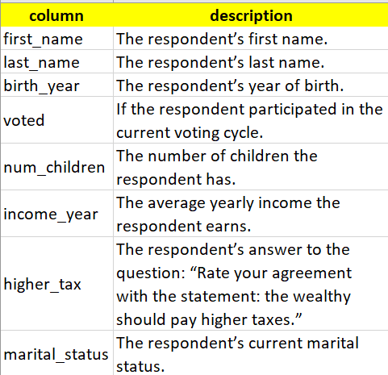

**Load the Data**

```python
# import libraries and load data
import pandas as pd

census = pd.read_excel("us_census_data.xlsx")
```

**Call the .head() method on the census dataframe to view the first five rows**

```python
# 1st 5 rows
census.head()
```

|  | first_name | last_name | birth_year | voted | num_children | income_year | higher_tax | marital_status |
| --- | --- | --- | --- | --- | --- | --- | --- | --- |
| 0 | Denise | Ratke | 2005 | False | 0 | 92129.41 | disagree | single |
| 1 | Hali | Cummerata | 1987 | False | 0 | 75649.17 | neutral | divorced |
| 2 | Salomon | Orn | 1992 | True | 2 | 166313.45 | agree | single |
| 3 | Sarina | Schiller | 1965 | False | 2 | 71704.81 | strongly agree | married |
| 4 | Gust | Abernathy | 1945 | False | 2 | 143316.08 | agree | married |

**Compare the values returned from the .head() method with the data types of each variable by calling .dtypes on the census dataframe**

```python
# census.dtypes
census.dtypes
```

```
first_name         object
last_name          object
birth_year         object
voted                bool
num_children        int64
income_year       float64
higher_tax         object
marital_status     object
dtype: object
```

Inference :

1. first_name , last_name : these are nominal
2. birth_year : should be converted to integer because this can be counted
3. voted : this is correct (yes/no)
4. higher_tax : this should be ordinal (ordered)
5. marital_status : this should be nominal due to no order

**The manager of the census would like to know the average birth year of the respondents. We were able to see from .dtypes that birth_year has been assigned the str datatype whereas it should be expressed in int.**

**Print the unique values of the variable using the .unique() method**

```python
# unique values in birth_year
census['birth_year'].unique()
```

```
array([2005, 1987, 1992, 1965, 1945, 1951, 1963, 1949, 1950, 1971, 2007,
       1944, 1995, 1973, 1946, 1954, 1994, 1989, 1947, 1993, 1976, 1984,
       'missing', 1966, 1941, 2000, 1953, 1956, 1960, 2001, 1980, 1955,
       1985, 1996, 1968, 1979, 2006, 1962, 1981, 1959, 1977, 1978, 1983,
       1957, 1961, 1982, 2002, 1998, 1999, 1952, 1940, 1986, 1958],
      dtype=object)
```

```python
# how many unique values in birth_year
len(census['birth_year'].unique())
```

```
53
```

**There appears to be a missing value in the birth_year column. With some research you find that the respondent’s birth year is 1967.Use the .replace() method to replace the missing value with 1967, so that the data type can be changed to int.**  
**Now recheck the values in birth_year by calling the .unique() method**

```python
# replace "missing" in "birth_year" with 1967
census['birth_year'] = census['birth_year'].replace('missing' , 1967)

# unique values in birth_year
census['birth_year'].unique()
```

```
array([2005, 1987, 1992, 1965, 1945, 1951, 1963, 1949, 1950, 1971, 2007,
       1944, 1995, 1973, 1946, 1954, 1994, 1989, 1947, 1993, 1976, 1984,
       1967, 1966, 1941, 2000, 1953, 1956, 1960, 2001, 1980, 1955, 1985,
       1996, 1968, 1979, 2006, 1962, 1981, 1959, 1977, 1978, 1983, 1957,
       1961, 1982, 2002, 1998, 1999, 1952, 1940, 1986, 1958], dtype=int64)
```

```python
# how many unique values in birth_year
len(census['birth_year'].unique())
```

```
53
```

**Now that we have adjusted the values in the birth_year variable, change the datatype from str to int and print the datatypes of the census dataframe with .dtypes**

```python
# alterning the datatype for birth_year from string to integer
census['birth_year'] = census['birth_year'].astype(int)
```

```python
# printing the datatypes
census.dtypes
```

```
first_name         object
last_name          object
birth_year          int32
voted                bool
num_children        int64
income_year       float64
higher_tax         object
marital_status     object
dtype: object
```

**Having assigned birth_year to the appropriate data type, print the average birth year of the respondents to the census using the pandas .mean() method.**

```python
# mean birth_year
census['birth_year'].mean()
```

```
1973.4
```

```python
census.head().T
```

|  | 0 | 1 | 2 | 3 | 4 |
| --- | --- | --- | --- | --- | --- |
| first_name | Denise | Hali | Salomon | Sarina | Gust |
| last_name | Ratke | Cummerata | Orn | Schiller | Abernathy |
| birth_year | 2005 | 1987 | 1992 | 1965 | 1945 |
| voted | False | False | True | False | False |
| num_children | 0 | 0 | 2 | 2 | 2 |
| income_year | 92129.4 | 75649.2 | 166313 | 71704.8 | 143316 |
| higher_tax | disagree | neutral | agree | strongly agree | agree |
| marital_status | single | divorced | single | married | married |

**Your manager would like to set an order to the higher_tax variable so that: strongly disagree < disagree < neutral < agree < strongly agree.**

**Convert the higher_tax variable to the category data type with the appropriate order, then print the new order using the .unique() method**

```python
# create a new column higher_tax_le which is a copy of higher_tax
census['higher_tax_le'] = census['higher_tax']

# convert higher_tax_le to categorical
census['higher_tax_le'] = pd.Categorical(census['higher_tax_le'], ['strongly disagree', 'disagree', 'neutral', 'agree', 'strongly agree'], ordered=True)
```

```python
# review unique values in higher_tax
census.head()
```

|  | first_name | last_name | birth_year | voted | num_children | income_year | higher_tax | marital_status | higher_tax_le |
| --- | --- | --- | --- | --- | --- | --- | --- | --- | --- |
| 0 | Denise | Ratke | 2005 | False | 0 | 92129.41 | disagree | single | disagree |
| 1 | Hali | Cummerata | 1987 | False | 0 | 75649.17 | neutral | divorced | neutral |
| 2 | Salomon | Orn | 1992 | True | 2 | 166313.45 | agree | single | agree |
| 3 | Sarina | Schiller | 1965 | False | 2 | 71704.81 | strongly agree | married | strongly agree |
| 4 | Gust | Abernathy | 1945 | False | 2 | 143316.08 | agree | married | agree |

**Your manager would also like to know the median sentiment of the respondents on the issue of higher taxes for the wealthy.**  
**Label encode the higher_tax variable and print the median using the pandas .median() method**

```python
# Use cat.code to label encode the higher_tax_le variable
census['higher_tax_le'] = census['higher_tax_le'].cat.codes
```

```python
# print out the median of the higher_tax variable
census['higher_tax_le'].median()
```

```
2.0
```

```python
census.head().T
```

|  | 0 | 1 | 2 | 3 | 4 |
| --- | --- | --- | --- | --- | --- |
| first_name | Denise | Hali | Salomon | Sarina | Gust |
| last_name | Ratke | Cummerata | Orn | Schiller | Abernathy |
| birth_year | 2005 | 1987 | 1992 | 1965 | 1945 |
| voted | False | False | True | False | False |
| num_children | 0 | 0 | 2 | 2 | 2 |
| income_year | 92129.4 | 75649.2 | 166313 | 71704.8 | 143316 |
| higher_tax | disagree | neutral | agree | strongly agree | agree |
| marital_status | single | divorced | single | married | married |
| higher_tax_le | 1 | 2 | 3 | 4 | 3 |

**Your manager is interested in using machine learning models on the census data in the future. To help, let’s One-Hot Encode marital_status to create binary variables of each category. Use the pandas get_dummies() method to One-Hot Encode the marital_status variable**

```python
# Use get_dummies to OHE the marital_status
census = pd.get_dummies(census, columns=['marital_status'])
```

```python
# print 1st 5 rows to validate
census.head().T
```

|  | 0 | 1 | 2 | 3 | 4 |
| --- | --- | --- | --- | --- | --- |
| first_name | Denise | Hali | Salomon | Sarina | Gust |
| last_name | Ratke | Cummerata | Orn | Schiller | Abernathy |
| birth_year | 2005 | 1987 | 1992 | 1965 | 1945 |
| voted | False | False | True | False | False |
| num_children | 0 | 0 | 2 | 2 | 2 |
| income_year | 92129.4 | 75649.2 | 166313 | 71704.8 | 143316 |
| higher_tax | disagree | neutral | agree | strongly agree | agree |
| higher_tax_le | 1 | 2 | 3 | 4 | 3 |
| marital_status_divorced | 0 | 1 | 0 | 0 | 0 |
| marital_status_married | 0 | 0 | 0 | 1 | 1 |
| marital_status_single | 1 | 0 | 1 | 0 | 0 |
| marital_status_widowed | 0 | 0 | 0 | 0 | 0 |

```python
census.info()
```

```
<class 'pandas.core.frame.DataFrame'>
RangeIndex: 100 entries, 0 to 99
Data columns (total 12 columns):
 #   Column                   Non-Null Count  Dtype
---  ------                   --------------  -----
 0   first_name               100 non-null    object
 1   last_name                100 non-null    object
 2   birth_year               100 non-null    int32
 3   voted                    100 non-null    bool
 4   num_children             100 non-null    int64
 5   income_year              100 non-null    float64
 6   higher_tax               100 non-null    object
 7   higher_tax_le            100 non-null    int8
 8   marital_status_divorced  100 non-null    uint8
 9   marital_status_married   100 non-null    uint8
 10  marital_status_single    100 non-null    uint8
 11  marital_status_widowed   100 non-null    uint8
dtypes: bool(1), float64(1), int32(1), int64(1), int8(1), object(3), uint8(4)
memory usage: 5.0+ KB
```

# Summary :

1. We have discovered the different types of variables you will encounter when working with data and their corresponding data types in Python.
2. We have explored datasets with .head().
3. We have assessed categories within variables with the .unique() method.
4. We have practiced ways to check the data type of variables like the .dtypes attribute and .info() method.
5. We have altered data with the .replace() method.
6. We have learned how to change the data types of variables using the .astype() method.
7. We have investigated the pandas category data type.
8. We have developed your Label Encoding and One-Hot Encoding skills with the .cat.codes accessor and pd.get_dummies() method.